# San Francisco Rent Analysis

# Rents in San Francsisco 2000-2018

```r
# download directly off tidytuesdaygithub repo
rent <- readr::read_csv('https://raw.githubusercontent.com/rfordatascience/tidytuesday/master/data/2022/2022-07-05/rent.csv')
```

What are the variable types? Do they all correspond to what they really are? Which variables have most missing values?

> There are 8 character variables and 9 numeric variables. They all seem to correspond to what they really are. The variable with the most missing values is “descr”.

```r
# YOUR CODE GOES HERE
skimr::skim(rent)
```

Data summary

| Name | rent |
| --- | --- |
| Number of rows | 200796 |
| Number of columns | 17 |
| _______________________ |  |
| Column type frequency: |  |
| character | 8 |
| numeric | 9 |
| ________________________ |  |
| Group variables | None |

**Variable type: character**

| skim_variable | n_missing | complete_rate | min | max | empty | n_unique | whitespace |
| --- | --- | --- | --- | --- | --- | --- | --- |
| post_id | 0 | 1.00 | 9 | 14 | 0 | 200796 | 0 |
| nhood | 0 | 1.00 | 4 | 43 | 0 | 167 | 0 |
| city | 0 | 1.00 | 5 | 19 | 0 | 104 | 0 |
| county | 1394 | 0.99 | 4 | 13 | 0 | 10 | 0 |
| address | 196888 | 0.02 | 1 | 38 | 0 | 2869 | 0 |
| title | 2517 | 0.99 | 2 | 298 | 0 | 184961 | 0 |
| descr | 197542 | 0.02 | 13 | 16975 | 0 | 3025 | 0 |
| details | 192780 | 0.04 | 4 | 595 | 0 | 7667 | 0 |

**Variable type: numeric**

| skim_variable | n_missing | complete_rate | mean | sd | p0 | p25 | p50 | p75 | p100 | hist |
| --- | --- | --- | --- | --- | --- | --- | --- | --- | --- | --- |
| date | 0 | 1.00 | 2.01e+07 | 44694.07 | 2.00e+07 | 2.01e+07 | 2.01e+07 | 2.01e+07 | 2.02e+07 | ▁▇▁▆▃ |
| year | 0 | 1.00 | 2.01e+03 | 4.48 | 2.00e+03 | 2.00e+03 | 2.01e+03 | 2.01e+03 | 2.02e+03 | ▁▇▁▆▃ |
| price | 0 | 1.00 | 2.14e+03 | 1427.75 | 2.20e+02 | 1.30e+03 | 1.80e+03 | 2.50e+03 | 4.00e+04 | ▇▁▁▁▁ |
| beds | 6608 | 0.97 | 1.89e+00 | 1.08 | 0.00e+00 | 1.00e+00 | 2.00e+00 | 3.00e+00 | 1.20e+01 | ▇▂▁▁▁ |
| baths | 158121 | 0.21 | 1.68e+00 | 0.69 | 1.00e+00 | 1.00e+00 | 2.00e+00 | 2.00e+00 | 8.00e+00 | ▇▁▁▁▁ |
| sqft | 136117 | 0.32 | 1.20e+03 | 5000.22 | 8.00e+01 | 7.50e+02 | 1.00e+03 | 1.36e+03 | 9.00e+05 | ▇▁▁▁▁ |
| room_in_apt | 0 | 1.00 | 0.00e+00 | 0.04 | 0.00e+00 | 0.00e+00 | 0.00e+00 | 0.00e+00 | 1.00e+00 | ▇▁▁▁▁ |
| lat | 193145 | 0.04 | 3.77e+01 | 0.35 | 3.36e+01 | 3.74e+01 | 3.78e+01 | 3.78e+01 | 4.04e+01 | ▁▁▅▇▁ |
| lon | 196484 | 0.02 | -1.22e+02 | 0.78 | -1.23e+02 | -1.22e+02 | -1.22e+02 | -1.22e+02 | -7.42e+01 | ▇▁▁▁▁ |

```r
summary(rent)
```

```
##    post_id               date               year         nhood
##  Length:200796      Min.   :20000902   Min.   :2000   Length:200796
##  Class :character   1st Qu.:20050227   1st Qu.:2005   Class :character
##  Mode  :character   Median :20110924   Median :2011   Mode  :character
##                     Mean   :20095718   Mean   :2010
##                     3rd Qu.:20120805   3rd Qu.:2012
##                     Max.   :20180717   Max.   :2018
##
##      city              county              price            beds
##  Length:200796      Length:200796      Min.   :  220   Min.   : 0
##  Class :character   Class :character   1st Qu.: 1295   1st Qu.: 1
##  Mode  :character   Mode  :character   Median : 1800   Median : 2
##                                        Mean   : 2135   Mean   : 2
##                                        3rd Qu.: 2505   3rd Qu.: 3
##                                        Max.   :40000   Max.   :12
##                                                        NA's   :6608
##      baths             sqft         room_in_apt      address
##  Min.   :1        Min.   :    80   Min.   :0.000   Length:200796
##  1st Qu.:1        1st Qu.:   750   1st Qu.:0.000   Class :character
##  Median :2        Median :  1000   Median :0.000   Mode  :character
##  Mean   :2        Mean   :  1202   Mean   :0.001
##  3rd Qu.:2        3rd Qu.:  1360   3rd Qu.:0.000
##  Max.   :8        Max.   :900000   Max.   :1.000
##  NA's   :158121   NA's   :136117
##       lat              lon            title              descr
##  Min.   :34       Min.   :-123     Length:200796      Length:200796
##  1st Qu.:37       1st Qu.:-122     Class :character   Class :character
##  Median :38       Median :-122     Mode  :character   Mode  :character
##  Mean   :38       Mean   :-122
##  3rd Qu.:38       3rd Qu.:-122
##  Max.   :40       Max.   : -74
##  NA's   :193145   NA's   :196484
##    details
##  Length:200796
##  Class :character
##  Mode  :character
##
##
##
##
```

Make a plot that shows the top 20 cities in terms of % of classifieds between 2000-2018. You need to calculate the number of listings by city, and then convert that number to a %.

The final graph should look like this

[figure not shown]

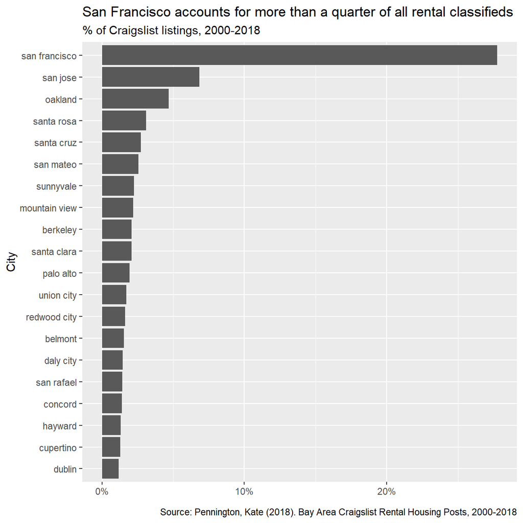

```r
# YOUR CODE GOES HERE
rent %>%
  count(city, sort=TRUE) %>%
  mutate(prop = n/sum(n)) %>%
  slice_max(order_by = prop, n=20) %>%
  mutate(city = fct_reorder(city, prop)) %>%

  ggplot(aes(x=prop, y= city)) +
  geom_col() +
  labs(title = "San Francisco accounts for more than a quarter of all rental classifieds",
       subtitle = "% of Craigslist listings, 2000-2018",
       caption = "Source: Pennington, Kate (2018). Bay Area Craigslist Rental Housing Posts, 2000-2018", y = "City", x = element_blank()) +
  scale_x_continuous(labels = scales::percent)
```

Make a plot that shows the evolution of median prices in San Francisco for 0, 1, 2, and 3 bedrooms listings. The final graph should look like this

[figure not shown]

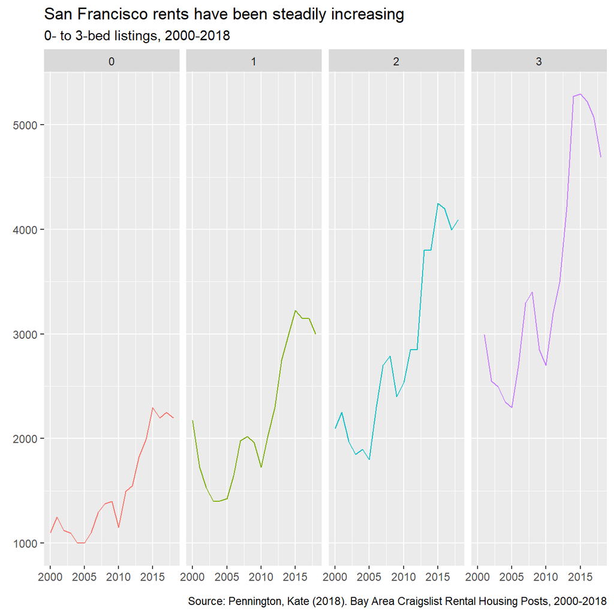

```r
# YOUR CODE GOES HERE
rent %>%
  filter(city == "san francisco", beds<=3) %>%
  group_by(year, beds) %>%
  summarise(median_price = median(price)) %>%

ggplot( mapping=aes(x=year, y=median_price, colour = factor(beds))) +
  geom_line() +
  facet_wrap(~beds, nrow=1)+
  theme(legend.position = "none") +
  labs(title = "San Francisco rents have been steadily increasing",
       subtitle = "0- to 3-bed listings, 2000-2018",
       caption = "Source: Pennington, Kate (2018). Bay Area Craigslist Rental Housing Posts, 2000-2018", y = element_blank(), x = element_blank())
```

Finally, make a plot that shows median rental prices for the top 12 cities in the Bay area. Your final graph should look like this

[figure not shown]

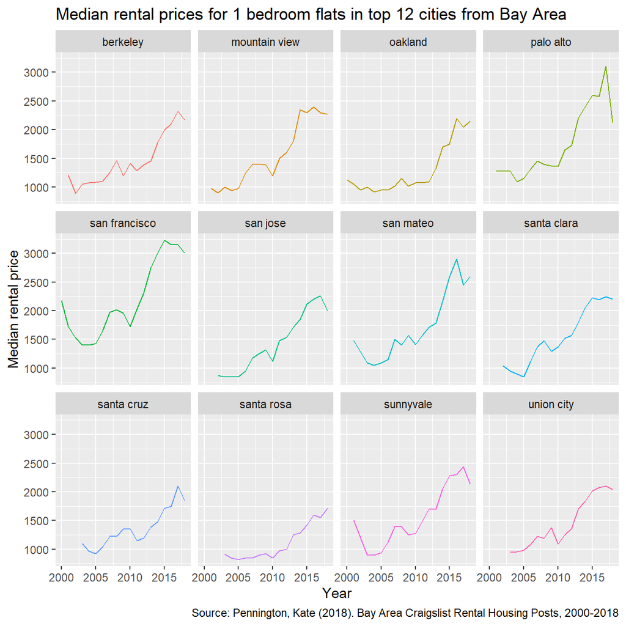

```r
# YOUR CODE GOES HERE
rent %>%
  filter(city %in% c("san francisco", "san jose", "oakland", "santa rosa", "santa cruz", "san mateo", "sunnyvale", "mountain view", "berkeley", "santa clara", "palo alto", "union city"), beds == 1)%>%
  group_by(city,year) %>%
  summarise(median_price = median(price), city)%>%

  ggplot(aes(x=year, y=median_price, color=city)) +
  geom_line() +
  facet_wrap(~city, nrow=3)+
  theme(legend.position = "none") +
  labs(title = "Median rental prices for 1 bedroom flats in top 12 cities from Bay Area", x = "Year", y = "Median rental price", caption = "Source: Pennington, Kate (2018). Bay Area Craigslist Rental Housing Posts, 2000-2018")
```

What can you infer from these plots? Don’t just explain what’s in the graph, but speculate or tell a short story (1-2 paragraphs max).

> The general trend that can be seen across the cities in the Bay area is that the rent has decreased in the years following the dot.com bubble (2001-2004), after which it increased rapidly prior to the housing market crash and global financial crisis that started in 2007-2008. After 2010 rents started increasing rapidly again until the economic slowdown that commenced at the end of the decade.